# Risk Factor Analysis

## Outcome Variable

**Outcome Variable:** wast_rec90d

## Predictor Variables

**Intervention Variable:** enstunt

**Adjustment Set:**

- arm
- sex
- W_mage
- meducyrs
- feducyrs
- vagbrth
- single
- brthmon
- W_parity
- delta_W_mage
- delta_meducyrs
- delta_feducyrs
- delta_vagbrth
- delta_single
- delta_brthmon
- delta_W_parity

## Stratifying Variables

The analysis was stratified on these variable(s):

- agecat
- studyid
- country

## Data Summary

| agecat | studyid | country | enstunt | wast_rec90d | n_cell | n |
| --- | --- | --- | --- | --- | --- | --- |
| 0-24 months | ki0047075b-MAL-ED | BANGLADESH | 0 | 0 | 34 | 124 |
| 0-24 months | ki0047075b-MAL-ED | BANGLADESH | 0 | 1 | 61 | 124 |
| 0-24 months | ki0047075b-MAL-ED | BANGLADESH | 1 | 0 | 10 | 124 |
| 0-24 months | ki0047075b-MAL-ED | BANGLADESH | 1 | 1 | 19 | 124 |
| 0-24 months | ki0047075b-MAL-ED | BRAZIL | 0 | 0 | 5 | 24 |
| 0-24 months | ki0047075b-MAL-ED | BRAZIL | 0 | 1 | 15 | 24 |
| 0-24 months | ki0047075b-MAL-ED | BRAZIL | 1 | 0 | 1 | 24 |
| 0-24 months | ki0047075b-MAL-ED | BRAZIL | 1 | 1 | 3 | 24 |
| 0-24 months | ki0047075b-MAL-ED | INDIA | 0 | 0 | 51 | 181 |
| 0-24 months | ki0047075b-MAL-ED | INDIA | 0 | 1 | 92 | 181 |
| 0-24 months | ki0047075b-MAL-ED | INDIA | 1 | 0 | 20 | 181 |
| 0-24 months | ki0047075b-MAL-ED | INDIA | 1 | 1 | 18 | 181 |
| 0-24 months | ki0047075b-MAL-ED | NEPAL | 0 | 0 | 16 | 98 |
| 0-24 months | ki0047075b-MAL-ED | NEPAL | 0 | 1 | 63 | 98 |
| 0-24 months | ki0047075b-MAL-ED | NEPAL | 1 | 0 | 4 | 98 |
| 0-24 months | ki0047075b-MAL-ED | NEPAL | 1 | 1 | 15 | 98 |
| 0-24 months | ki0047075b-MAL-ED | PERU | 0 | 0 | 3 | 35 |
| 0-24 months | ki0047075b-MAL-ED | PERU | 0 | 1 | 21 | 35 |
| 0-24 months | ki0047075b-MAL-ED | PERU | 1 | 0 | 3 | 35 |
| 0-24 months | ki0047075b-MAL-ED | PERU | 1 | 1 | 8 | 35 |
| 0-24 months | ki0047075b-MAL-ED | SOUTH AFRICA | 0 | 0 | 17 | 87 |
| 0-24 months | ki0047075b-MAL-ED | SOUTH AFRICA | 0 | 1 | 57 | 87 |
| 0-24 months | ki0047075b-MAL-ED | SOUTH AFRICA | 1 | 0 | 1 | 87 |
| 0-24 months | ki0047075b-MAL-ED | SOUTH AFRICA | 1 | 1 | 12 | 87 |
| 0-24 months | ki0047075b-MAL-ED | TANZANIA, UNITED REPUBLIC OF | 0 | 0 | 8 | 51 |
| 0-24 months | ki0047075b-MAL-ED | TANZANIA, UNITED REPUBLIC OF | 0 | 1 | 31 | 51 |
| 0-24 months | ki0047075b-MAL-ED | TANZANIA, UNITED REPUBLIC OF | 1 | 0 | 1 | 51 |
| 0-24 months | ki0047075b-MAL-ED | TANZANIA, UNITED REPUBLIC OF | 1 | 1 | 11 | 51 |
| 0-24 months | ki1000108-CMC-V-BCS-2002 | INDIA | 0 | 0 | 88 | 324 |
| 0-24 months | ki1000108-CMC-V-BCS-2002 | INDIA | 0 | 1 | 159 | 324 |

[output cut: 338 more lines]

The following strata were considered:

- agecat: 0-24 months, studyid: ki0047075b-MAL-ED, country: BANGLADESH
- agecat: 0-24 months, studyid: ki0047075b-MAL-ED, country: BRAZIL
- agecat: 0-24 months, studyid: ki0047075b-MAL-ED, country: INDIA
- agecat: 0-24 months, studyid: ki0047075b-MAL-ED, country: NEPAL
- agecat: 0-24 months, studyid: ki0047075b-MAL-ED, country: PERU
- agecat: 0-24 months, studyid: ki0047075b-MAL-ED, country: SOUTH AFRICA
- agecat: 0-24 months, studyid: ki0047075b-MAL-ED, country: TANZANIA, UNITED REPUBLIC OF
- agecat: 0-24 months, studyid: ki1000108-CMC-V-BCS-2002, country: INDIA
- agecat: 0-24 months, studyid: ki1000108-IRC, country: INDIA
- agecat: 0-24 months, studyid: ki1000109-EE, country: PAKISTAN
- agecat: 0-24 months, studyid: ki1000109-ResPak, country: PAKISTAN
- agecat: 0-24 months, studyid: ki1000304b-SAS-CompFeed, country: INDIA
- agecat: 0-24 months, studyid: ki1000304b-SAS-FoodSuppl, country: INDIA
- agecat: 0-24 months, studyid: ki1017093-NIH-Birth, country: BANGLADESH
- agecat: 0-24 months, studyid: ki1017093b-PROVIDE, country: BANGLADESH
- agecat: 0-24 months, studyid: ki1017093c-NIH-Crypto, country: BANGLADESH
- agecat: 0-24 months, studyid: ki1066203-TanzaniaChild2, country: TANZANIA, UNITED REPUBLIC OF
- agecat: 0-24 months, studyid: ki1101329-Keneba, country: GAMBIA
- agecat: 0-24 months, studyid: ki1112895-Guatemala BSC, country: GUATEMALA
- agecat: 0-24 months, studyid: ki1112895-iLiNS-Zinc, country: BURKINA FASO
- agecat: 0-24 months, studyid: ki1113344-GMS-Nepal, country: NEPAL
- agecat: 0-24 months, studyid: ki1114097-CMIN, country: BANGLADESH
- agecat: 0-24 months, studyid: ki1114097-CONTENT, country: PERU
- agecat: 0-24 months, studyid: ki1119695-PROBIT, country: BELARUS
- agecat: 0-24 months, studyid: ki1126311-ZVITAMBO, country: ZIMBABWE
- agecat: 0-24 months, studyid: ki1135781-COHORTS, country: GUATEMALA
- agecat: 0-24 months, studyid: ki1135781-COHORTS, country: INDIA
- agecat: 0-24 months, studyid: ki1135781-COHORTS, country: PHILIPPINES
- agecat: 0-24 months, studyid: ki1148112-LCNI-5, country: MALAWI
- agecat: 0-24 months, studyid: kiGH5241-JiVitA-3, country: BANGLADESH
- agecat: 0-24 months, studyid: kiGH5241-JiVitA-4, country: BANGLADESH
- agecat: 0-6 months, studyid: ki0047075b-MAL-ED, country: BANGLADESH
- agecat: 0-6 months, studyid: ki0047075b-MAL-ED, country: BRAZIL
- agecat: 0-6 months, studyid: ki0047075b-MAL-ED, country: INDIA
- agecat: 0-6 months, studyid: ki0047075b-MAL-ED, country: NEPAL
- agecat: 0-6 months, studyid: ki0047075b-MAL-ED, country: PERU
- agecat: 0-6 months, studyid: ki0047075b-MAL-ED, country: SOUTH AFRICA
- agecat: 0-6 months, studyid: ki0047075b-MAL-ED, country: TANZANIA, UNITED REPUBLIC OF
- agecat: 0-6 months, studyid: ki1000108-CMC-V-BCS-2002, country: INDIA
- agecat: 0-6 months, studyid: ki1000108-IRC, country: INDIA
- agecat: 0-6 months, studyid: ki1000109-EE, country: PAKISTAN
- agecat: 0-6 months, studyid: ki1000109-ResPak, country: PAKISTAN
- agecat: 0-6 months, studyid: ki1000304b-SAS-CompFeed, country: INDIA
- agecat: 0-6 months, studyid: ki1000304b-SAS-FoodSuppl, country: INDIA
- agecat: 0-6 months, studyid: ki1017093-NIH-Birth, country: BANGLADESH
- agecat: 0-6 months, studyid: ki1017093b-PROVIDE, country: BANGLADESH
- agecat: 0-6 months, studyid: ki1017093c-NIH-Crypto, country: BANGLADESH
- agecat: 0-6 months, studyid: ki1066203-TanzaniaChild2, country: TANZANIA, UNITED REPUBLIC OF
- agecat: 0-6 months, studyid: ki1101329-Keneba, country: GAMBIA
- agecat: 0-6 months, studyid: ki1112895-Guatemala BSC, country: GUATEMALA
- agecat: 0-6 months, studyid: ki1113344-GMS-Nepal, country: NEPAL
- agecat: 0-6 months, studyid: ki1114097-CMIN, country: BANGLADESH
- agecat: 0-6 months, studyid: ki1114097-CONTENT, country: PERU
- agecat: 0-6 months, studyid: ki1119695-PROBIT, country: BELARUS
- agecat: 0-6 months, studyid: ki1126311-ZVITAMBO, country: ZIMBABWE
- agecat: 0-6 months, studyid: ki1135781-COHORTS, country: GUATEMALA
- agecat: 0-6 months, studyid: ki1135781-COHORTS, country: INDIA
- agecat: 0-6 months, studyid: ki1135781-COHORTS, country: PHILIPPINES
- agecat: 0-6 months, studyid: ki1148112-LCNI-5, country: MALAWI
- agecat: 0-6 months, studyid: kiGH5241-JiVitA-3, country: BANGLADESH
- agecat: 0-6 months, studyid: kiGH5241-JiVitA-4, country: BANGLADESH
- agecat: 6-24 months, studyid: ki0047075b-MAL-ED, country: BANGLADESH
- agecat: 6-24 months, studyid: ki0047075b-MAL-ED, country: BRAZIL
- agecat: 6-24 months, studyid: ki0047075b-MAL-ED, country: INDIA
- agecat: 6-24 months, studyid: ki0047075b-MAL-ED, country: NEPAL
- agecat: 6-24 months, studyid: ki0047075b-MAL-ED, country: PERU
- agecat: 6-24 months, studyid: ki0047075b-MAL-ED, country: SOUTH AFRICA
- agecat: 6-24 months, studyid: ki0047075b-MAL-ED, country: TANZANIA, UNITED REPUBLIC OF
- agecat: 6-24 months, studyid: ki1000108-CMC-V-BCS-2002, country: INDIA
- agecat: 6-24 months, studyid: ki1000108-IRC, country: INDIA
- agecat: 6-24 months, studyid: ki1000109-EE, country: PAKISTAN
- agecat: 6-24 months, studyid: ki1000109-ResPak, country: PAKISTAN
- agecat: 6-24 months, studyid: ki1000304b-SAS-CompFeed, country: INDIA
- agecat: 6-24 months, studyid: ki1000304b-SAS-FoodSuppl, country: INDIA
- agecat: 6-24 months, studyid: ki1017093-NIH-Birth, country: BANGLADESH
- agecat: 6-24 months, studyid: ki1017093b-PROVIDE, country: BANGLADESH
- agecat: 6-24 months, studyid: ki1017093c-NIH-Crypto, country: BANGLADESH
- agecat: 6-24 months, studyid: ki1066203-TanzaniaChild2, country: TANZANIA, UNITED REPUBLIC OF
- agecat: 6-24 months, studyid: ki1101329-Keneba, country: GAMBIA
- agecat: 6-24 months, studyid: ki1112895-Guatemala BSC, country: GUATEMALA
- agecat: 6-24 months, studyid: ki1112895-iLiNS-Zinc, country: BURKINA FASO
- agecat: 6-24 months, studyid: ki1113344-GMS-Nepal, country: NEPAL
- agecat: 6-24 months, studyid: ki1114097-CMIN, country: BANGLADESH
- agecat: 6-24 months, studyid: ki1114097-CONTENT, country: PERU
- agecat: 6-24 months, studyid: ki1119695-PROBIT, country: BELARUS
- agecat: 6-24 months, studyid: ki1126311-ZVITAMBO, country: ZIMBABWE
- agecat: 6-24 months, studyid: ki1135781-COHORTS, country: GUATEMALA
- agecat: 6-24 months, studyid: ki1135781-COHORTS, country: INDIA
- agecat: 6-24 months, studyid: ki1135781-COHORTS, country: PHILIPPINES
- agecat: 6-24 months, studyid: ki1148112-LCNI-5, country: MALAWI
- agecat: 6-24 months, studyid: kiGH5241-JiVitA-3, country: BANGLADESH
- agecat: 6-24 months, studyid: kiGH5241-JiVitA-4, country: BANGLADESH

### Dropped Strata

Some strata were dropped due to rare outcomes:

- agecat: 0-24 months, studyid: ki0047075b-MAL-ED, country: BRAZIL
- agecat: 0-24 months, studyid: ki0047075b-MAL-ED, country: NEPAL
- agecat: 0-24 months, studyid: ki0047075b-MAL-ED, country: PERU
- agecat: 0-24 months, studyid: ki0047075b-MAL-ED, country: SOUTH AFRICA
- agecat: 0-24 months, studyid: ki0047075b-MAL-ED, country: TANZANIA, UNITED REPUBLIC OF
- agecat: 0-24 months, studyid: ki1000304b-SAS-FoodSuppl, country: INDIA
- agecat: 0-24 months, studyid: ki1114097-CONTENT, country: PERU
- agecat: 0-24 months, studyid: ki1119695-PROBIT, country: BELARUS
- agecat: 0-24 months, studyid: ki1135781-COHORTS, country: GUATEMALA
- agecat: 0-6 months, studyid: ki0047075b-MAL-ED, country: BANGLADESH
- agecat: 0-6 months, studyid: ki0047075b-MAL-ED, country: BRAZIL
- agecat: 0-6 months, studyid: ki0047075b-MAL-ED, country: INDIA
- agecat: 0-6 months, studyid: ki0047075b-MAL-ED, country: NEPAL
- agecat: 0-6 months, studyid: ki0047075b-MAL-ED, country: PERU
- agecat: 0-6 months, studyid: ki0047075b-MAL-ED, country: SOUTH AFRICA
- agecat: 0-6 months, studyid: ki0047075b-MAL-ED, country: TANZANIA, UNITED REPUBLIC OF
- agecat: 0-6 months, studyid: ki1000304b-SAS-FoodSuppl, country: INDIA
- agecat: 0-6 months, studyid: ki1017093c-NIH-Crypto, country: BANGLADESH
- agecat: 0-6 months, studyid: ki1066203-TanzaniaChild2, country: TANZANIA, UNITED REPUBLIC OF
- agecat: 0-6 months, studyid: ki1112895-Guatemala BSC, country: GUATEMALA
- agecat: 0-6 months, studyid: ki1114097-CONTENT, country: PERU
- agecat: 0-6 months, studyid: ki1119695-PROBIT, country: BELARUS
- agecat: 0-6 months, studyid: ki1135781-COHORTS, country: GUATEMALA
- agecat: 0-6 months, studyid: ki1148112-LCNI-5, country: MALAWI
- agecat: 6-24 months, studyid: ki0047075b-MAL-ED, country: BRAZIL
- agecat: 6-24 months, studyid: ki0047075b-MAL-ED, country: NEPAL
- agecat: 6-24 months, studyid: ki0047075b-MAL-ED, country: PERU
- agecat: 6-24 months, studyid: ki0047075b-MAL-ED, country: SOUTH AFRICA
- agecat: 6-24 months, studyid: ki0047075b-MAL-ED, country: TANZANIA, UNITED REPUBLIC OF
- agecat: 6-24 months, studyid: ki1000304b-SAS-FoodSuppl, country: INDIA
- agecat: 6-24 months, studyid: ki1017093c-NIH-Crypto, country: BANGLADESH
- agecat: 6-24 months, studyid: ki1114097-CONTENT, country: PERU
- agecat: 6-24 months, studyid: ki1119695-PROBIT, country: BELARUS
- agecat: 6-24 months, studyid: ki1135781-COHORTS, country: GUATEMALA
- agecat: 6-24 months, studyid: ki1135781-COHORTS, country: INDIA
- agecat: 6-24 months, studyid: kiGH5241-JiVitA-3, country: BANGLADESH

## Methods Detail

We’re interested in the causal parameters $E[Y_a]$ for all values of $a \in \mathcal{A}$. These parameters represent the mean outcome if, possibly contrary to fact, we intervened to set all units to have $A=a$. Under the randomization and positivity assumptions, these are identified by the statistical parameters $\psi_a=E_W[E_{Y|A,W}(Y|A=a,W)]$. In addition, we’re interested in the mean of $Y$, $E[Y]$ under no intervention (the observed mean). We will estimate these parameters by using SuperLearner to fit the relevant likelihood factors – $E_{Y|A,W}(Y|A=a,W)$ and $p(A=a|W)$, and then updating our likelihood fit using a joint TMLE.

For unadjusted analyses ($W=\{\}$), initial likelihoods were estimated using Lrnr_glm to estimate the simple $E(Y|A)$ and Lrnr_mean to estimate $p(A)$. For adjusted analyses, a small library containing Lrnr_glmnet, Lrnr_xgboost, and Lrnr_mean was used.

Having estimated these parameters, we will then use the delta method to estimate relative risks and attributable risks relative to a prespecified baseline level of $A$.

# Results Detail

## Results Plots

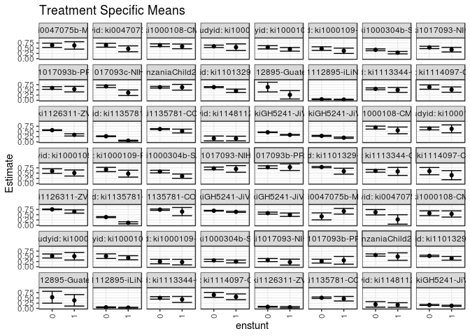

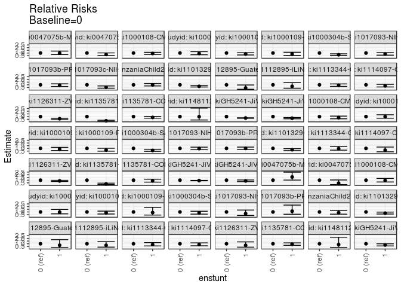

[figure not shown]

[figure not shown]

## Results Table

### Parameter: TSM

| agecat | studyid | country | intervention_level | baseline_level | estimate | ci_lower | ci_upper |
| --- | --- | --- | --- | --- | --- | --- | --- |
| 0-24 months | ki0047075b-MAL-ED | BANGLADESH | 0 | NA | 0.6420252 | 0.5409466 | 0.7431038 |
| 0-24 months | ki0047075b-MAL-ED | BANGLADESH | 1 | NA | 0.6333466 | 0.4557496 | 0.8109435 |
| 0-24 months | ki0047075b-MAL-ED | INDIA | 0 | NA | 0.6438201 | 0.5517751 | 0.7358651 |
| 0-24 months | ki0047075b-MAL-ED | INDIA | 1 | NA | 0.4720698 | 0.3316898 | 0.6124498 |
| 0-24 months | ki1000108-CMC-V-BCS-2002 | INDIA | 0 | NA | 0.6436143 | 0.5787832 | 0.7084454 |
| 0-24 months | ki1000108-CMC-V-BCS-2002 | INDIA | 1 | NA | 0.5864947 | 0.4751529 | 0.6978364 |
| 0-24 months | ki1000108-IRC | INDIA | 0 | NA | 0.5926233 | 0.5362921 | 0.6489546 |
| 0-24 months | ki1000108-IRC | INDIA | 1 | NA | 0.5494724 | 0.3922813 | 0.7066634 |
| 0-24 months | ki1000109-EE | PAKISTAN | 0 | NA | 0.5448457 | 0.4675239 | 0.6221674 |
| 0-24 months | ki1000109-EE | PAKISTAN | 1 | NA | 0.4478368 | 0.3599107 | 0.5357629 |
| 0-24 months | ki1000109-ResPak | PAKISTAN | 0 | NA | 0.4826663 | 0.3966583 | 0.5686742 |
| 0-24 months | ki1000109-ResPak | PAKISTAN | 1 | NA | 0.3781002 | 0.2500035 | 0.5061968 |
| 0-24 months | ki1000304b-SAS-CompFeed | INDIA | 0 | NA | 0.4244738 | 0.3811848 | 0.4677628 |
| 0-24 months | ki1000304b-SAS-CompFeed | INDIA | 1 | NA | 0.2881872 | 0.2306763 | 0.3456980 |
| 0-24 months | ki1017093-NIH-Birth | BANGLADESH | 0 | NA | 0.5375385 | 0.4808663 | 0.5942108 |
| 0-24 months | ki1017093-NIH-Birth | BANGLADESH | 1 | NA | 0.4317410 | 0.3202995 | 0.5431824 |
| 0-24 months | ki1017093b-PROVIDE | BANGLADESH | 0 | NA | 0.5888607 | 0.5261921 | 0.6515293 |
| 0-24 months | ki1017093b-PROVIDE | BANGLADESH | 1 | NA | 0.5335850 | 0.4012578 | 0.6659123 |
| 0-24 months | ki1017093c-NIH-Crypto | BANGLADESH | 0 | NA | 0.6671337 | 0.6093386 | 0.7249287 |
| 0-24 months | ki1017093c-NIH-Crypto | BANGLADESH | 1 | NA | 0.3628640 | 0.2301151 | 0.4956129 |
| 0-24 months | ki1066203-TanzaniaChild2 | TANZANIA, UNITED REPUBLIC OF | 0 | NA | 0.6272299 | 0.5879702 | 0.6664895 |
| 0-24 months | ki1066203-TanzaniaChild2 | TANZANIA, UNITED REPUBLIC OF | 1 | NA | 0.6235827 | 0.4867907 | 0.7603747 |
| 0-24 months | ki1101329-Keneba | GAMBIA | 0 | NA | 0.6302667 | 0.6052502 | 0.6552831 |
| 0-24 months | ki1101329-Keneba | GAMBIA | 1 | NA | 0.4534131 | 0.3720315 | 0.5347946 |
| 0-24 months | ki1112895-Guatemala BSC | GUATEMALA | 0 | NA | 0.6315789 | 0.4004047 | 0.8627532 |
| 0-24 months | ki1112895-Guatemala BSC | GUATEMALA | 1 | NA | 0.2631579 | 0.0627483 | 0.4635675 |
| 0-24 months | ki1112895-iLiNS-Zinc | BURKINA FASO | 0 | NA | 0.0501247 | 0.0309828 | 0.0692666 |
| 0-24 months | ki1112895-iLiNS-Zinc | BURKINA FASO | 1 | NA | 0.0361670 | 0.0161981 | 0.0561358 |
| 0-24 months | ki1113344-GMS-Nepal | NEPAL | 0 | NA | 0.5466627 | 0.5012294 | 0.5920959 |
| 0-24 months | ki1113344-GMS-Nepal | NEPAL | 1 | NA | 0.4952356 | 0.3769448 | 0.6135264 |

[output cut: 82 more lines]

### Parameter: E(Y)

| agecat | studyid | country | intervention_level | baseline_level | estimate | ci_lower | ci_upper |
| --- | --- | --- | --- | --- | --- | --- | --- |
| 0-24 months | ki0047075b-MAL-ED | BANGLADESH | NA | NA | 0.6451613 | 0.5593015 | 0.7310211 |
| 0-24 months | ki0047075b-MAL-ED | INDIA | NA | NA | 0.6077348 | 0.5286689 | 0.6868008 |
| 0-24 months | ki1000108-CMC-V-BCS-2002 | INDIA | NA | NA | 0.6296296 | 0.5734927 | 0.6857666 |
| 0-24 months | ki1000108-IRC | INDIA | NA | NA | 0.5898734 | 0.5376978 | 0.6420491 |
| 0-24 months | ki1000109-EE | PAKISTAN | NA | NA | 0.5046440 | 0.4456009 | 0.5636870 |
| 0-24 months | ki1000109-ResPak | PAKISTAN | NA | NA | 0.4509804 | 0.3794254 | 0.5225353 |
| 0-24 months | ki1000304b-SAS-CompFeed | INDIA | NA | NA | 0.3808354 | 0.3457640 | 0.4159068 |
| 0-24 months | ki1017093-NIH-Birth | BANGLADESH | NA | NA | 0.5201900 | 0.4695846 | 0.5707955 |
| 0-24 months | ki1017093b-PROVIDE | BANGLADESH | NA | NA | 0.5811688 | 0.5245443 | 0.6377934 |
| 0-24 months | ki1017093c-NIH-Crypto | BANGLADESH | NA | NA | 0.6225806 | 0.5684562 | 0.6767051 |
| 0-24 months | ki1066203-TanzaniaChild2 | TANZANIA, UNITED REPUBLIC OF | NA | NA | 0.6269285 | 0.5892870 | 0.6645700 |
| 0-24 months | ki1101329-Keneba | GAMBIA | NA | NA | 0.6105033 | 0.5863646 | 0.6346419 |
| 0-24 months | ki1112895-Guatemala BSC | GUATEMALA | NA | NA | 0.4473684 | 0.2760904 | 0.6186464 |
| 0-24 months | ki1112895-iLiNS-Zinc | BURKINA FASO | NA | NA | 0.0439024 | 0.0298653 | 0.0579396 |
| 0-24 months | ki1113344-GMS-Nepal | NEPAL | NA | NA | 0.5396579 | 0.4973524 | 0.5819633 |
| 0-24 months | ki1114097-CMIN | BANGLADESH | NA | NA | 0.5789474 | 0.5004470 | 0.6574477 |
| 0-24 months | ki1126311-ZVITAMBO | ZIMBABWE | NA | NA | 0.5432918 | 0.5268968 | 0.5596869 |
| 0-24 months | ki1135781-COHORTS | INDIA | NA | NA | 0.2418325 | 0.2254819 | 0.2581831 |
| 0-24 months | ki1135781-COHORTS | PHILIPPINES | NA | NA | 0.6068680 | 0.5823645 | 0.6313715 |
| 0-24 months | ki1148112-LCNI-5 | MALAWI | NA | NA | 0.1645570 | 0.0832789 | 0.2458350 |
| 0-24 months | kiGH5241-JiVitA-3 | BANGLADESH | NA | NA | 0.4221371 | 0.4110175 | 0.4332567 |
| 0-24 months | kiGH5241-JiVitA-4 | BANGLADESH | NA | NA | 0.2585790 | 0.2392503 | 0.2779077 |
| 0-6 months | ki1000108-CMC-V-BCS-2002 | INDIA | NA | NA | 0.6716418 | 0.6057305 | 0.7375531 |
| 0-6 months | ki1000108-IRC | INDIA | NA | NA | 0.6375000 | 0.5751450 | 0.6998550 |
| 0-6 months | ki1000109-EE | PAKISTAN | NA | NA | 0.5669291 | 0.4800274 | 0.6538309 |
| 0-6 months | ki1000109-ResPak | PAKISTAN | NA | NA | 0.6194690 | 0.5292383 | 0.7096997 |
| 0-6 months | ki1000304b-SAS-CompFeed | INDIA | NA | NA | 0.5131965 | 0.4596632 | 0.5667297 |
| 0-6 months | ki1017093-NIH-Birth | BANGLADESH | NA | NA | 0.7130045 | 0.6535890 | 0.7724200 |
| 0-6 months | ki1017093b-PROVIDE | BANGLADESH | NA | NA | 0.7837838 | 0.7252863 | 0.8422812 |
| 0-6 months | ki1101329-Keneba | GAMBIA | NA | NA | 0.7720994 | 0.7419223 | 0.8022766 |
| 0-6 months | ki1113344-GMS-Nepal | NEPAL | NA | NA | 0.6045627 | 0.5449300 | 0.6641955 |
| 0-6 months | ki1114097-CMIN | BANGLADESH | NA | NA | 0.5192308 | 0.3806687 | 0.6577929 |
| 0-6 months | ki1126311-ZVITAMBO | ZIMBABWE | NA | NA | 0.7475189 | 0.7305656 | 0.7644721 |
| 0-6 months | ki1135781-COHORTS | INDIA | NA | NA | 0.3585746 | 0.3363886 | 0.3807606 |
| 0-6 months | ki1135781-COHORTS | PHILIPPINES | NA | NA | 0.7367021 | 0.7051294 | 0.7682749 |
| 0-6 months | kiGH5241-JiVitA-3 | BANGLADESH | NA | NA | 0.6751162 | 0.6617750 | 0.6884574 |
| 0-6 months | kiGH5241-JiVitA-4 | BANGLADESH | NA | NA | 0.5587703 | 0.5173487 | 0.6001920 |
| 6-24 months | ki0047075b-MAL-ED | BANGLADESH | NA | NA | 0.4918033 | 0.3610932 | 0.6225134 |
| 6-24 months | ki0047075b-MAL-ED | INDIA | NA | NA | 0.5368421 | 0.4223932 | 0.6512910 |
| 6-24 months | ki1000108-CMC-V-BCS-2002 | INDIA | NA | NA | 0.5609756 | 0.4682842 | 0.6536670 |
| 6-24 months | ki1000108-IRC | INDIA | NA | NA | 0.5161290 | 0.4322562 | 0.6000019 |
| 6-24 months | ki1000109-EE | PAKISTAN | NA | NA | 0.4642857 | 0.3910729 | 0.5374985 |
| 6-24 months | ki1000109-ResPak | PAKISTAN | NA | NA | 0.2417582 | 0.1565924 | 0.3269241 |
| 6-24 months | ki1000304b-SAS-CompFeed | INDIA | NA | NA | 0.2854123 | 0.2436284 | 0.3271961 |
| 6-24 months | ki1017093-NIH-Birth | BANGLADESH | NA | NA | 0.3030303 | 0.2377927 | 0.3682679 |
| 6-24 months | ki1017093b-PROVIDE | BANGLADESH | NA | NA | 0.2764228 | 0.1950773 | 0.3577682 |
| 6-24 months | ki1066203-TanzaniaChild2 | TANZANIA, UNITED REPUBLIC OF | NA | NA | 0.5576407 | 0.5054408 | 0.6098407 |
| 6-24 months | ki1101329-Keneba | GAMBIA | NA | NA | 0.5045290 | 0.4730969 | 0.5359611 |
| 6-24 months | ki1112895-Guatemala BSC | GUATEMALA | NA | NA | 0.4642857 | 0.2621560 | 0.6664155 |
| 6-24 months | ki1112895-iLiNS-Zinc | BURKINA FASO | NA | NA | 0.0439024 | 0.0298653 | 0.0579396 |
| 6-24 months | ki1113344-GMS-Nepal | NEPAL | NA | NA | 0.4947368 | 0.4401559 | 0.5493178 |
| 6-24 months | ki1114097-CMIN | BANGLADESH | NA | NA | 0.6014493 | 0.5131344 | 0.6897641 |
| 6-24 months | ki1126311-ZVITAMBO | ZIMBABWE | NA | NA | 0.0739051 | 0.0584895 | 0.0893208 |
| 6-24 months | ki1135781-COHORTS | PHILIPPINES | NA | NA | 0.5026681 | 0.4688378 | 0.5364984 |
| 6-24 months | ki1148112-LCNI-5 | MALAWI | NA | NA | 0.1733333 | 0.0886479 | 0.2580188 |
| 6-24 months | kiGH5241-JiVitA-4 | BANGLADESH | NA | NA | 0.1490765 | 0.1314900 | 0.1666630 |

### Parameter: RR

| agecat | studyid | country | intervention_level | baseline_level | estimate | ci_lower | ci_upper |
| --- | --- | --- | --- | --- | --- | --- | --- |
| 0-24 months | ki0047075b-MAL-ED | BANGLADESH | 0 | 0 | 1.0000000 | 1.0000000 | 1.0000000 |
| 0-24 months | ki0047075b-MAL-ED | BANGLADESH | 1 | 0 | 0.9864823 | 0.7144714 | 1.3620523 |
| 0-24 months | ki0047075b-MAL-ED | INDIA | 0 | 0 | 1.0000000 | 1.0000000 | 1.0000000 |
| 0-24 months | ki0047075b-MAL-ED | INDIA | 1 | 0 | 0.7332325 | 0.5269088 | 1.0203473 |
| 0-24 months | ki1000108-CMC-V-BCS-2002 | INDIA | 0 | 0 | 1.0000000 | 1.0000000 | 1.0000000 |
| 0-24 months | ki1000108-CMC-V-BCS-2002 | INDIA | 1 | 0 | 0.9112518 | 0.7353358 | 1.1292526 |
| 0-24 months | ki1000108-IRC | INDIA | 0 | 0 | 1.0000000 | 1.0000000 | 1.0000000 |
| 0-24 months | ki1000108-IRC | INDIA | 1 | 0 | 0.9271866 | 0.6858444 | 1.2534547 |
| 0-24 months | ki1000109-EE | PAKISTAN | 0 | 0 | 1.0000000 | 1.0000000 | 1.0000000 |
| 0-24 months | ki1000109-EE | PAKISTAN | 1 | 0 | 0.8219517 | 0.6447568 | 1.0478442 |
| 0-24 months | ki1000109-ResPak | PAKISTAN | 0 | 0 | 1.0000000 | 1.0000000 | 1.0000000 |
| 0-24 months | ki1000109-ResPak | PAKISTAN | 1 | 0 | 0.7833573 | 0.5360839 | 1.1446878 |
| 0-24 months | ki1000304b-SAS-CompFeed | INDIA | 0 | 0 | 1.0000000 | 1.0000000 | 1.0000000 |
| 0-24 months | ki1000304b-SAS-CompFeed | INDIA | 1 | 0 | 0.6789280 | 0.5426058 | 0.8494992 |
| 0-24 months | ki1017093-NIH-Birth | BANGLADESH | 0 | 0 | 1.0000000 | 1.0000000 | 1.0000000 |
| 0-24 months | ki1017093-NIH-Birth | BANGLADESH | 1 | 0 | 0.8031814 | 0.6077011 | 1.0615423 |
| 0-24 months | ki1017093b-PROVIDE | BANGLADESH | 0 | 0 | 1.0000000 | 1.0000000 | 1.0000000 |
| 0-24 months | ki1017093b-PROVIDE | BANGLADESH | 1 | 0 | 0.9061312 | 0.6910390 | 1.1881729 |
| 0-24 months | ki1017093c-NIH-Crypto | BANGLADESH | 0 | 0 | 1.0000000 | 1.0000000 | 1.0000000 |
| 0-24 months | ki1017093c-NIH-Crypto | BANGLADESH | 1 | 0 | 0.5439150 | 0.3735407 | 0.7919982 |
| 0-24 months | ki1066203-TanzaniaChild2 | TANZANIA, UNITED REPUBLIC OF | 0 | 0 | 1.0000000 | 1.0000000 | 1.0000000 |
| 0-24 months | ki1066203-TanzaniaChild2 | TANZANIA, UNITED REPUBLIC OF | 1 | 0 | 0.9941853 | 0.7913871 | 1.2489520 |
| 0-24 months | ki1101329-Keneba | GAMBIA | 0 | 0 | 1.0000000 | 1.0000000 | 1.0000000 |
| 0-24 months | ki1101329-Keneba | GAMBIA | 1 | 0 | 0.7193987 | 0.5988899 | 0.8641564 |
| 0-24 months | ki1112895-Guatemala BSC | GUATEMALA | 0 | 0 | 1.0000000 | 1.0000000 | 1.0000000 |
| 0-24 months | ki1112895-Guatemala BSC | GUATEMALA | 1 | 0 | 0.4166667 | 0.1790304 | 0.9697297 |
| 0-24 months | ki1112895-iLiNS-Zinc | BURKINA FASO | 0 | 0 | 1.0000000 | 1.0000000 | 1.0000000 |
| 0-24 months | ki1112895-iLiNS-Zinc | BURKINA FASO | 1 | 0 | 0.7215398 | 0.3693886 | 1.4094089 |
| 0-24 months | ki1113344-GMS-Nepal | NEPAL | 0 | 0 | 1.0000000 | 1.0000000 | 1.0000000 |
| 0-24 months | ki1113344-GMS-Nepal | NEPAL | 1 | 0 | 0.9059254 | 0.7031974 | 1.1670988 |

[output cut: 82 more lines]

### Parameter: PAR

| agecat | studyid | country | intervention_level | baseline_level | estimate | ci_lower | ci_upper |
| --- | --- | --- | --- | --- | --- | --- | --- |
| 0-24 months | ki0047075b-MAL-ED | BANGLADESH | 0 | NA | 0.0031361 | -0.0419177 | 0.0481898 |
| 0-24 months | ki0047075b-MAL-ED | INDIA | 0 | NA | -0.0360853 | -0.0745313 | 0.0023608 |
| 0-24 months | ki1000108-CMC-V-BCS-2002 | INDIA | 0 | NA | -0.0139847 | -0.0444907 | 0.0165214 |
| 0-24 months | ki1000108-IRC | INDIA | 0 | NA | -0.0027499 | -0.0237250 | 0.0182252 |
| 0-24 months | ki1000109-EE | PAKISTAN | 0 | NA | -0.0402017 | -0.0953067 | 0.0149033 |
| 0-24 months | ki1000109-ResPak | PAKISTAN | 0 | NA | -0.0316859 | -0.0785234 | 0.0151516 |
| 0-24 months | ki1000304b-SAS-CompFeed | INDIA | 0 | NA | -0.0436384 | -0.0671419 | -0.0201350 |
| 0-24 months | ki1017093-NIH-Birth | BANGLADESH | 0 | NA | -0.0173485 | -0.0391764 | 0.0044794 |
| 0-24 months | ki1017093b-PROVIDE | BANGLADESH | 0 | NA | -0.0076918 | -0.0305071 | 0.0151234 |
| 0-24 months | ki1017093c-NIH-Crypto | BANGLADESH | 0 | NA | -0.0445530 | -0.0673637 | -0.0217423 |
| 0-24 months | ki1066203-TanzaniaChild2 | TANZANIA, UNITED REPUBLIC OF | 0 | NA | -0.0003014 | -0.0121903 | 0.0115875 |
| 0-24 months | ki1101329-Keneba | GAMBIA | 0 | NA | -0.0197634 | -0.0294822 | -0.0100447 |
| 0-24 months | ki1112895-Guatemala BSC | GUATEMALA | 0 | NA | -0.1842105 | -0.3548689 | -0.0135521 |
| 0-24 months | ki1112895-iLiNS-Zinc | BURKINA FASO | 0 | NA | -0.0062223 | -0.0175644 | 0.0051199 |
| 0-24 months | ki1113344-GMS-Nepal | NEPAL | 0 | NA | -0.0070048 | -0.0255061 | 0.0114965 |
| 0-24 months | ki1114097-CMIN | BANGLADESH | 0 | NA | -0.0538757 | -0.1260624 | 0.0183111 |
| 0-24 months | ki1126311-ZVITAMBO | ZIMBABWE | 0 | NA | -0.0193590 | -0.0246006 | -0.0141173 |
| 0-24 months | ki1135781-COHORTS | INDIA | 0 | NA | -0.0293502 | -0.0344150 | -0.0242854 |
| 0-24 months | ki1135781-COHORTS | PHILIPPINES | 0 | NA | -0.0078880 | -0.0147585 | -0.0010175 |
| 0-24 months | ki1148112-LCNI-5 | MALAWI | 0 | NA | -0.0021097 | -0.1014388 | 0.0972194 |
| 0-24 months | kiGH5241-JiVitA-3 | BANGLADESH | 0 | NA | -0.0379199 | -0.0454566 | -0.0303832 |
| 0-24 months | kiGH5241-JiVitA-4 | BANGLADESH | 0 | NA | -0.0304090 | -0.0443149 | -0.0165031 |
| 0-6 months | ki1000108-CMC-V-BCS-2002 | INDIA | 0 | NA | -0.0123543 | -0.0471778 | 0.0224692 |
| 0-6 months | ki1000108-IRC | INDIA | 0 | NA | -0.0051695 | -0.0273198 | 0.0169809 |
| 0-6 months | ki1000109-EE | PAKISTAN | 0 | NA | -0.0304147 | -0.1014336 | 0.0406042 |
| 0-6 months | ki1000109-ResPak | PAKISTAN | 0 | NA | -0.0509723 | -0.1110651 | 0.0091206 |
| 0-6 months | ki1000304b-SAS-CompFeed | INDIA | 0 | NA | -0.0587887 | -0.0920556 | -0.0255219 |
| 0-6 months | ki1017093-NIH-Birth | BANGLADESH | 0 | NA | -0.0097352 | -0.0372515 | 0.0177811 |
| 0-6 months | ki1017093b-PROVIDE | BANGLADESH | 0 | NA | -0.0001668 | -0.0214738 | 0.0211401 |
| 0-6 months | ki1101329-Keneba | GAMBIA | 0 | NA | -0.0148728 | -0.0253553 | -0.0043904 |
| 0-6 months | ki1113344-GMS-Nepal | NEPAL | 0 | NA | -0.0016258 | -0.0232124 | 0.0199607 |
| 0-6 months | ki1114097-CMIN | BANGLADESH | 0 | NA | -0.0745192 | -0.1852886 | 0.0362501 |
| 0-6 months | ki1126311-ZVITAMBO | ZIMBABWE | 0 | NA | -0.0062423 | -0.0109788 | -0.0015057 |
| 0-6 months | ki1135781-COHORTS | INDIA | 0 | NA | -0.0263432 | -0.0328349 | -0.0198516 |
| 0-6 months | ki1135781-COHORTS | PHILIPPINES | 0 | NA | -0.0039253 | -0.0114735 | 0.0036229 |
| 0-6 months | kiGH5241-JiVitA-3 | BANGLADESH | 0 | NA | -0.0141286 | -0.0223957 | -0.0058614 |
| 0-6 months | kiGH5241-JiVitA-4 | BANGLADESH | 0 | NA | -0.0156064 | -0.0395861 | 0.0083733 |
| 6-24 months | ki0047075b-MAL-ED | BANGLADESH | 0 | NA | 0.0731986 | -0.0009247 | 0.1473219 |
| 6-24 months | ki0047075b-MAL-ED | INDIA | 0 | NA | -0.0795963 | -0.1465625 | -0.0126300 |
| 6-24 months | ki1000108-CMC-V-BCS-2002 | INDIA | 0 | NA | -0.0079846 | -0.0690583 | 0.0530891 |
| 6-24 months | ki1000108-IRC | INDIA | 0 | NA | 0.0015180 | -0.0368466 | 0.0398826 |
| 6-24 months | ki1000109-EE | PAKISTAN | 0 | NA | -0.0435827 | -0.1204053 | 0.0332399 |
| 6-24 months | ki1000109-ResPak | PAKISTAN | 0 | NA | -0.0082418 | -0.0590999 | 0.0426164 |
| 6-24 months | ki1000304b-SAS-CompFeed | INDIA | 0 | NA | -0.0199480 | -0.0499608 | 0.0100648 |
| 6-24 months | ki1017093-NIH-Birth | BANGLADESH | 0 | NA | -0.0179574 | -0.0476357 | 0.0117210 |
| 6-24 months | ki1017093b-PROVIDE | BANGLADESH | 0 | NA | 0.0083815 | -0.0348405 | 0.0516035 |
| 6-24 months | ki1066203-TanzaniaChild2 | TANZANIA, UNITED REPUBLIC OF | 0 | NA | -0.0032233 | -0.0224520 | 0.0160054 |
| 6-24 months | ki1101329-Keneba | GAMBIA | 0 | NA | -0.0156576 | -0.0284664 | -0.0028488 |
| 6-24 months | ki1112895-Guatemala BSC | GUATEMALA | 0 | NA | -0.0690476 | -0.2585251 | 0.1204298 |
| 6-24 months | ki1112895-iLiNS-Zinc | BURKINA FASO | 0 | NA | -0.0072716 | -0.0187282 | 0.0041849 |
| 6-24 months | ki1113344-GMS-Nepal | NEPAL | 0 | NA | -0.0059567 | -0.0313509 | 0.0194375 |
| 6-24 months | ki1114097-CMIN | BANGLADESH | 0 | NA | -0.0434328 | -0.1252116 | 0.0383461 |
| 6-24 months | ki1126311-ZVITAMBO | ZIMBABWE | 0 | NA | -0.0034311 | -0.0090795 | 0.0022173 |
| 6-24 months | ki1135781-COHORTS | PHILIPPINES | 0 | NA | -0.0049702 | -0.0158265 | 0.0058861 |
| 6-24 months | ki1148112-LCNI-5 | MALAWI | 0 | NA | -0.0189744 | -0.1308691 | 0.0929204 |
| 6-24 months | kiGH5241-JiVitA-4 | BANGLADESH | 0 | NA | -0.0141573 | -0.0279697 | -0.0003450 |

### Parameter: PAF

| agecat | studyid | country | intervention_level | baseline_level | estimate | ci_lower | ci_upper |
| --- | --- | --- | --- | --- | --- | --- | --- |
| 0-24 months | ki0047075b-MAL-ED | BANGLADESH | 0 | NA | 0.0048609 | -0.0675573 | 0.0723666 |
| 0-24 months | ki0047075b-MAL-ED | INDIA | 0 | NA | -0.0593767 | -0.1240620 | 0.0015863 |
| 0-24 months | ki1000108-CMC-V-BCS-2002 | INDIA | 0 | NA | -0.0222109 | -0.0717974 | 0.0250814 |
| 0-24 months | ki1000108-IRC | INDIA | 0 | NA | -0.0046619 | -0.0408576 | 0.0302752 |
| 0-24 months | ki1000109-EE | PAKISTAN | 0 | NA | -0.0796635 | -0.1958682 | 0.0252494 |
| 0-24 months | ki1000109-ResPak | PAKISTAN | 0 | NA | -0.0702600 | -0.1798283 | 0.0291329 |
| 0-24 months | ki1000304b-SAS-CompFeed | INDIA | 0 | NA | -0.1145861 | -0.1783758 | -0.0542496 |
| 0-24 months | ki1017093-NIH-Birth | BANGLADESH | 0 | NA | -0.0333503 | -0.0760391 | 0.0076449 |
| 0-24 months | ki1017093b-PROVIDE | BANGLADESH | 0 | NA | -0.0132351 | -0.0531811 | 0.0251957 |
| 0-24 months | ki1017093c-NIH-Crypto | BANGLADESH | 0 | NA | -0.0715618 | -0.1096578 | -0.0347737 |
| 0-24 months | ki1066203-TanzaniaChild2 | TANZANIA, UNITED REPUBLIC OF | 0 | NA | -0.0004807 | -0.0196259 | 0.0183049 |
| 0-24 months | ki1101329-Keneba | GAMBIA | 0 | NA | -0.0323723 | -0.0486082 | -0.0163878 |
| 0-24 months | ki1112895-Guatemala BSC | GUATEMALA | 0 | NA | -0.4117647 | -0.9077869 | -0.0447077 |
| 0-24 months | ki1112895-iLiNS-Zinc | BURKINA FASO | 0 | NA | -0.1417296 | -0.4293537 | 0.0880169 |
| 0-24 months | ki1113344-GMS-Nepal | NEPAL | 0 | NA | -0.0129801 | -0.0479114 | 0.0207868 |
| 0-24 months | ki1114097-CMIN | BANGLADESH | 0 | NA | -0.0930580 | -0.2268384 | 0.0261344 |
| 0-24 months | ki1126311-ZVITAMBO | ZIMBABWE | 0 | NA | -0.0356328 | -0.0454228 | -0.0259344 |
| 0-24 months | ki1135781-COHORTS | INDIA | 0 | NA | -0.1213659 | -0.1420767 | -0.1010306 |
| 0-24 months | ki1135781-COHORTS | PHILIPPINES | 0 | NA | -0.0129980 | -0.0244022 | -0.0017207 |
| 0-24 months | ki1148112-LCNI-5 | MALAWI | 0 | NA | -0.0128205 | -0.8402175 | 0.4425630 |
| 0-24 months | kiGH5241-JiVitA-3 | BANGLADESH | 0 | NA | -0.0898284 | -0.1079168 | -0.0720354 |
| 0-24 months | kiGH5241-JiVitA-4 | BANGLADESH | 0 | NA | -0.1176004 | -0.1724821 | -0.0652877 |
| 0-6 months | ki1000108-CMC-V-BCS-2002 | INDIA | 0 | NA | -0.0183942 | -0.0717825 | 0.0323347 |
| 0-6 months | ki1000108-IRC | INDIA | 0 | NA | -0.0081090 | -0.0434755 | 0.0260589 |
| 0-6 months | ki1000109-EE | PAKISTAN | 0 | NA | -0.0536481 | -0.1873519 | 0.0649998 |
| 0-6 months | ki1000109-ResPak | PAKISTAN | 0 | NA | -0.0822838 | -0.1857678 | 0.0121690 |
| 0-6 months | ki1000304b-SAS-CompFeed | INDIA | 0 | NA | -0.1145540 | -0.1828378 | -0.0502122 |
| 0-6 months | ki1017093-NIH-Birth | BANGLADESH | 0 | NA | -0.0136538 | -0.0530631 | 0.0242807 |
| 0-6 months | ki1017093b-PROVIDE | BANGLADESH | 0 | NA | -0.0002129 | -0.0277699 | 0.0266053 |
| 0-6 months | ki1101329-Keneba | GAMBIA | 0 | NA | -0.0192628 | -0.0330672 | -0.0056429 |
| 0-6 months | ki1113344-GMS-Nepal | NEPAL | 0 | NA | -0.0026893 | -0.0390429 | 0.0323925 |
| 0-6 months | ki1114097-CMIN | BANGLADESH | 0 | NA | -0.1435185 | -0.3845587 | 0.0555586 |
| 0-6 months | ki1126311-ZVITAMBO | ZIMBABWE | 0 | NA | -0.0083506 | -0.0147214 | -0.0020198 |
| 0-6 months | ki1135781-COHORTS | INDIA | 0 | NA | -0.0734665 | -0.0918321 | -0.0554098 |
| 0-6 months | ki1135781-COHORTS | PHILIPPINES | 0 | NA | -0.0053282 | -0.0156425 | 0.0048813 |
| 0-6 months | kiGH5241-JiVitA-3 | BANGLADESH | 0 | NA | -0.0209276 | -0.0332684 | -0.0087342 |
| 0-6 months | kiGH5241-JiVitA-4 | BANGLADESH | 0 | NA | -0.0279299 | -0.0718598 | 0.0141995 |
| 6-24 months | ki0047075b-MAL-ED | BANGLADESH | 0 | NA | 0.1488372 | -0.0337380 | 0.2991666 |
| 6-24 months | ki0047075b-MAL-ED | INDIA | 0 | NA | -0.1482675 | -0.2872539 | -0.0242877 |
| 6-24 months | ki1000108-CMC-V-BCS-2002 | INDIA | 0 | NA | -0.0142334 | -0.1289506 | 0.0888269 |
| 6-24 months | ki1000108-IRC | INDIA | 0 | NA | 0.0029411 | -0.0742827 | 0.0746138 |
| 6-24 months | ki1000109-EE | PAKISTAN | 0 | NA | -0.0938704 | -0.2720402 | 0.0593438 |
| 6-24 months | ki1000109-ResPak | PAKISTAN | 0 | NA | -0.0340909 | -0.2649033 | 0.1546041 |
| 6-24 months | ki1000304b-SAS-CompFeed | INDIA | 0 | NA | -0.0698919 | -0.1800122 | 0.0299518 |
| 6-24 months | ki1017093-NIH-Birth | BANGLADESH | 0 | NA | -0.0592593 | -0.1620039 | 0.0344007 |
| 6-24 months | ki1017093b-PROVIDE | BANGLADESH | 0 | NA | 0.0303214 | -0.1392634 | 0.1746627 |
| 6-24 months | ki1066203-TanzaniaChild2 | TANZANIA, UNITED REPUBLIC OF | 0 | NA | -0.0057803 | -0.0408873 | 0.0281426 |
| 6-24 months | ki1101329-Keneba | GAMBIA | 0 | NA | -0.0310341 | -0.0568381 | -0.0058601 |
| 6-24 months | ki1112895-Guatemala BSC | GUATEMALA | 0 | NA | -0.1487179 | -0.6420119 | 0.1963804 |
| 6-24 months | ki1112895-iLiNS-Zinc | BURKINA FASO | 0 | NA | -0.1656317 | -0.4563383 | 0.0670456 |
| 6-24 months | ki1113344-GMS-Nepal | NEPAL | 0 | NA | -0.0120402 | -0.0647296 | 0.0380419 |
| 6-24 months | ki1114097-CMIN | BANGLADESH | 0 | NA | -0.0722135 | -0.2181203 | 0.0562166 |
| 6-24 months | ki1126311-ZVITAMBO | ZIMBABWE | 0 | NA | -0.0464256 | -0.1248808 | 0.0265577 |
| 6-24 months | ki1135781-COHORTS | PHILIPPINES | 0 | NA | -0.0098877 | -0.0317181 | 0.0114808 |
| 6-24 months | ki1148112-LCNI-5 | MALAWI | 0 | NA | -0.1094675 | -1.0014729 | 0.3849939 |
| 6-24 months | kiGH5241-JiVitA-4 | BANGLADESH | 0 | NA | -0.0949670 | -0.1910972 | -0.0065951 |